# Homework Tidy Verse

Patricia Vail

2024-02-12

#### Load libraries

```r
library(tidyverse)
```

#### Read in data

```r
getwd()
```

```
## [1] "/Users/pvail/Documents/Courses/Comp Bio/TidyVerse"
```

```r
#Load data
surveys <- read_csv("/Users/pvail/Documents/Courses/Comp Bio/TidyVerse/Class Repo/CM515-course-2024/modules/04_Tidyverse/diversity.csv")
```

### Tidyverse Day 1

#### Q1: What is the class of the object surveys?

```r
#Q1
class(surveys)
```

```
## [1] "spec_tbl_df" "tbl_df"      "tbl"         "data.frame"
```

```r
str(surveys)
```

```
## spc_tbl_ [34,786 × 13] (S3: spec_tbl_df/tbl_df/tbl/data.frame)
##  $ record_id      : num [1:34786] 1 72 224 266 349 363 435 506 588 661 ...
##  $ month          : num [1:34786] 7 8 9 10 11 11 12 1 2 3 ...
##  $ day            : num [1:34786] 16 19 13 16 12 12 10 8 18 11 ...
##  $ year           : num [1:34786] 1977 1977 1977 1977 1977 ...
##  $ plot_id        : num [1:34786] 2 2 2 2 2 2 2 2 2 2 ...
##  $ species_id     : chr [1:34786] "NL" "NL" "NL" "NL" ...
##  $ sex            : chr [1:34786] "M" "M" NA NA ...
##  $ hindfoot_length: num [1:34786] 32 31 NA NA NA NA NA NA NA NA ...
##  $ weight         : num [1:34786] NA NA NA NA NA NA NA NA 218 NA ...
##  $ genus          : chr [1:34786] "Neotoma" "Neotoma" "Neotoma" "Neotoma" ...
##  $ species        : chr [1:34786] "albigula" "albigula" "albigula" "albigula" ...
##  $ taxa           : chr [1:34786] "Rodent" "Rodent" "Rodent" "Rodent" ...
##  $ plot_type      : chr [1:34786] "Control" "Control" "Control" "Control" ...
##  - attr(*, "spec")=
##   .. cols(
##   ..   record_id = col_double(),
##   ..   month = col_double(),
##   ..   day = col_double(),
##   ..   year = col_double(),
##   ..   plot_id = col_double(),
##   ..   species_id = col_character(),
##   ..   sex = col_character(),
##   ..   hindfoot_length = col_double(),
##   ..   weight = col_double(),
##   ..   genus = col_character(),
##   ..   species = col_character(),
##   ..   taxa = col_character(),
##   ..   plot_type = col_character()
##   .. )
##  - attr(*, "problems")=<externalptr>
```

Surveys is a data frame

#### Q2: How many rows and how many columns are in the object?

Rows: 34786 Columns: 13

#### Q2: Create a data.frame (surveys_200) containing only the data in row 200 of the surveys dataset.

```r
#Q2
surveys[200,]
```

```
## # A tibble: 1 × 13
##   record_id month   day  year plot_id species_id sex   hindfoot_length weight
##       <dbl> <dbl> <dbl> <dbl>   <dbl> <chr>      <chr>           <dbl>  <dbl>
## 1     35212    12     7  2002       2 NL         M                  33    248
## # ℹ 4 more variables: genus <chr>, species <chr>, taxa <chr>, plot_type <chr>
```

```r
#Q3
nrows <- nrow(surveys)
surveys_last <- surveys[nrows,]
```

#### Q4: Change the columns taxa and genus in the surveys data frame into a factor.

```r
#Q4
surveys$taxa <- factor(surveys$taxa)
str(surveys)
```

```
## spc_tbl_ [34,786 × 13] (S3: spec_tbl_df/tbl_df/tbl/data.frame)
##  $ record_id      : num [1:34786] 1 72 224 266 349 363 435 506 588 661 ...
##  $ month          : num [1:34786] 7 8 9 10 11 11 12 1 2 3 ...
##  $ day            : num [1:34786] 16 19 13 16 12 12 10 8 18 11 ...
##  $ year           : num [1:34786] 1977 1977 1977 1977 1977 ...
##  $ plot_id        : num [1:34786] 2 2 2 2 2 2 2 2 2 2 ...
##  $ species_id     : chr [1:34786] "NL" "NL" "NL" "NL" ...
##  $ sex            : chr [1:34786] "M" "M" NA NA ...
##  $ hindfoot_length: num [1:34786] 32 31 NA NA NA NA NA NA NA NA ...
##  $ weight         : num [1:34786] NA NA NA NA NA NA NA NA 218 NA ...
##  $ genus          : chr [1:34786] "Neotoma" "Neotoma" "Neotoma" "Neotoma" ...
##  $ species        : chr [1:34786] "albigula" "albigula" "albigula" "albigula" ...
##  $ taxa           : Factor w/ 4 levels "Bird","Rabbit",..: 4 4 4 4 4 4 4 4 4 4 ...
##  $ plot_type      : chr [1:34786] "Control" "Control" "Control" "Control" ...
##  - attr(*, "spec")=
##   .. cols(
##   ..   record_id = col_double(),
##   ..   month = col_double(),
##   ..   day = col_double(),
##   ..   year = col_double(),
##   ..   plot_id = col_double(),
##   ..   species_id = col_character(),
##   ..   sex = col_character(),
##   ..   hindfoot_length = col_double(),
##   ..   weight = col_double(),
##   ..   genus = col_character(),
##   ..   species = col_character(),
##   ..   taxa = col_character(),
##   ..   plot_type = col_character()
##   .. )
##  - attr(*, "problems")=<externalptr>
```

```r
surveys$genus <- factor(surveys$genus)
str(surveys)
```

```
## spc_tbl_ [34,786 × 13] (S3: spec_tbl_df/tbl_df/tbl/data.frame)
##  $ record_id      : num [1:34786] 1 72 224 266 349 363 435 506 588 661 ...
##  $ month          : num [1:34786] 7 8 9 10 11 11 12 1 2 3 ...
##  $ day            : num [1:34786] 16 19 13 16 12 12 10 8 18 11 ...
##  $ year           : num [1:34786] 1977 1977 1977 1977 1977 ...
##  $ plot_id        : num [1:34786] 2 2 2 2 2 2 2 2 2 2 ...
##  $ species_id     : chr [1:34786] "NL" "NL" "NL" "NL" ...
##  $ sex            : chr [1:34786] "M" "M" NA NA ...
##  $ hindfoot_length: num [1:34786] 32 31 NA NA NA NA NA NA NA NA ...
##  $ weight         : num [1:34786] NA NA NA NA NA NA NA NA 218 NA ...
##  $ genus          : Factor w/ 26 levels "Ammodramus","Ammospermophilus",..: 13 13 13 13 13 13 13 13 13 13 ...
##  $ species        : chr [1:34786] "albigula" "albigula" "albigula" "albigula" ...
##  $ taxa           : Factor w/ 4 levels "Bird","Rabbit",..: 4 4 4 4 4 4 4 4 4 4 ...
##  $ plot_type      : chr [1:34786] "Control" "Control" "Control" "Control" ...
##  - attr(*, "spec")=
##   .. cols(
##   ..   record_id = col_double(),
##   ..   month = col_double(),
##   ..   day = col_double(),
##   ..   year = col_double(),
##   ..   plot_id = col_double(),
##   ..   species_id = col_character(),
##   ..   sex = col_character(),
##   ..   hindfoot_length = col_double(),
##   ..   weight = col_double(),
##   ..   genus = col_character(),
##   ..   species = col_character(),
##   ..   taxa = col_character(),
##   ..   plot_type = col_character()
##   .. )
##  - attr(*, "problems")=<externalptr>
```

#### Q5: Using the functions you learned before

##### Q5 A: How many rabbits were observed?

75 rabbits observed

```r
#Q5A
table(surveys$taxa)
```

```
##
##    Bird  Rabbit Reptile  Rodent
##     450      75      14   34247
```

##### Q5 B: How many different genera are in the genus column?

There are 26 genera in the genus column

```r
#Q5B
table(surveys$genus)
```

```
##
##       Ammodramus Ammospermophilus       Amphispiza          Baiomys
##                2              437              303               46
##      Calamospiza       Callipepla  Campylorhynchus      Chaetodipus
##               13               16               50             6029
##    Cnemidophorus         Crotalus        Dipodomys           Lizard
##                2                2            16167                4
##          Neotoma        Onychomys      Perognathus       Peromyscus
##             1252             3267             1629             2234
##           Pipilo        Pooecetes  Reithrodontomys           Rodent
##               52                8             2694               10
##       Sceloporus         Sigmodon          Sparrow     Spermophilus
##                6              233                4              249
##       Sylvilagus      Zonotrichia
##               75                2
```

#### Q6: Create new variable ‘sex’ by converting surveys$sex to a factor. Use addNA to add a factor level to ‘sex’ variable. Using the ‘sex’ variable, rename “NA”, “F”, and “M” factors to “undetermined”, “female”, and “male” respectively. Plot sex variable.

```r
#Q6
surveys$sex <- factor(surveys$sex)
sex <- surveys$sex
sex <- addNA(sex)
levels(sex)
```

```
## [1] "F" "M" NA
```

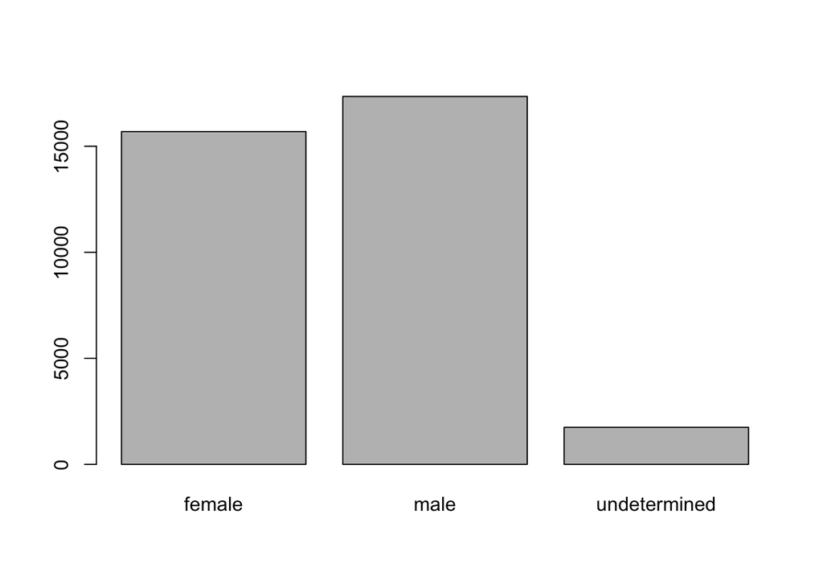

```r
levels(sex)[3] <- "undetermined"
levels(sex)[2] <- "male"
levels(sex)[1] <- "female"
plot(sex)
```

#### Q7: Recreate the barplot such that “undetermined” is first (before “female”).

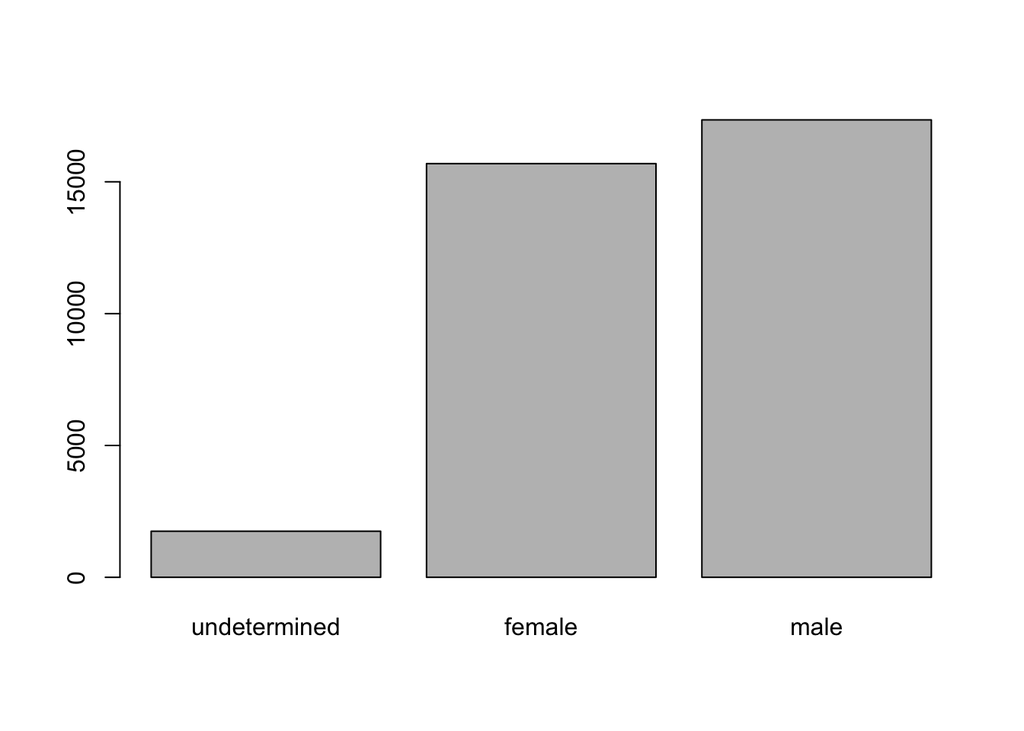

```r
#Q7
sex <- factor(sex, levels = c("undetermined", "female", "male"))
plot(sex)
```

#### Q8: Using pipes, subset the surveys data to include animals collected before 1995 and retain only the columns year, sex, and weight. View the tail() of the data.frame.

```r
#Q8
surveys %>%
  filter(year < 1995) %>%
  select(year, sex, weight) %>%
  tail()
```

```
## # A tibble: 6 × 3
##    year sex   weight
##   <dbl> <fct>  <dbl>
## 1  1987 <NA>      NA
## 2  1992 <NA>      NA
## 3  1989 M         11
## 4  1989 F         15
## 5  1992 <NA>      NA
## 6  1993 <NA>      NA
```

### Tidyverse Day 2

#### Q9: Create a new data frame from the surveys data that meets the following criteria:

##### Contains only the species_id column and a new column called hindfoot_cm which contains the hindfoot_length values (currently in mm) converted to centimeters. In this hindfoot_cm column, there are no NAs and all values are less than 3.

#### View the head() of the data.frame.

##### Hint: Think about how the commands should be ordered to produce this data frame!

```r
#Q9

surveys <- read_csv("/Users/pvail/Documents/Courses/Comp Bio/TidyVerse/Class Repo/CM515-course-2024/modules/04_Tidyverse/diversity.csv", show_col_types = FALSE)

surveys_new <-surveys %>%
  mutate(hindfoot_cm = hindfoot_length /10) %>%
  filter(hindfoot_cm < 3) %>%
  filter(!is.na(hindfoot_length)) %>%
  select(species_id, hindfoot_cm)
surveys_new %>% head()
```

```
## # A tibble: 6 × 2
##   species_id hindfoot_cm
##   <chr>            <dbl>
## 1 NL                 2.8
## 2 NL                 2.1
## 3 NL                 2.1
## 4 NL                 2.9
## 5 NL                 2.9
## 6 DM                 2.5
```

#### Q10: How many animals were caught in each plot_type surveyed?

```r
#Q10

surveys %>%
  #filter(plot_type != "Control")
  group_by(plot_type) %>%
  summarize("# Animals Caught" = n())
```

```
## # A tibble: 5 × 2
##   plot_type                 `# Animals Caught`
##   <chr>                                  <int>
## 1 Control                                15611
## 2 Long-term Krat Exclosure                5118
## 3 Rodent Exclosure                        4233
## 4 Short-term Krat Exclosure               5906
## 5 Spectab exclosure                       3918
```

#### Q11: Use group_by() and summarize() to find the mean, min, and max hindfoot length for each species (using species_id). Also add the number of observations (hint: see ?n).

```r
#Q11
surveys %>%
  group_by(species_id) %>%
  filter(!is.na(hindfoot_length)) %>%
  summarize(mean_length = mean(hindfoot_length),
            min_length = min(hindfoot_length), max_length = max(hindfoot_length), n = n())
```

```
## # A tibble: 25 × 5
##    species_id mean_length min_length max_length     n
##    <chr>            <dbl>      <dbl>      <dbl> <int>
##  1 AH                33           31         35     2
##  2 BA                13            6         16    45
##  3 DM                36.0         16         50  9972
##  4 DO                35.6         26         64  2887
##  5 DS                49.9         39         58  2132
##  6 NL                32.3         21         70  1074
##  7 OL                20.5         12         39   920
##  8 OT                20.3         13         50  2139
##  9 OX                19.1         13         21     8
## 10 PB                26.1          2         47  2864
## # ℹ 15 more rows
```

#### Q12: What was the heaviest animal measured in each year? Return the columns year, genus, species_id, and weight.

```r
#Q12

surveys %>%
  select(year, genus, species_id, weight) %>%
  filter(!is.na(weight)) %>%
  group_by(year) %>%
  filter(weight == max(weight))
```

```
## # A tibble: 27 × 4
## # Groups:   year [26]
##     year genus   species_id weight
##    <dbl> <chr>   <chr>       <dbl>
##  1  1979 Neotoma NL            274
##  2  1986 Neotoma NL            240
##  3  1987 Neotoma NL            278
##  4  1988 Neotoma NL            248
##  5  1992 Neotoma NL            220
##  6  1995 Neotoma NL            171
##  7  2000 Neotoma NL            265
##  8  2002 Neotoma NL            248
##  9  1978 Neotoma NL            232
## 10  1985 Neotoma NL            225
## # ℹ 17 more rows
```

#### Q13: Reshape the surveys data frame with year as columns, plot_id as rows, and the number of genera per plot as the values. You will need to summarize before reshaping, and use the function n_distinct() to get the number of unique genera within a particular chunk of data. It’s a powerful function! See ?n_distinct for more.

```r
#Q13
surveys_new <- surveys %>%
  group_by(year,plot_id) %>%
  summarize(n = n_distinct(genus)) %>%
  pivot_wider(names_from = year, values_from = n)
surveys_new
```

```
## # A tibble: 24 × 27
##    plot_id `1977` `1978` `1979` `1980` `1981` `1982` `1983` `1984` `1985` `1986`
##      <dbl>  <int>  <int>  <int>  <int>  <int>  <int>  <int>  <int>  <int>  <int>
##  1       1      2      3      4      7      5      6      7      6      4      3
##  2       2      6      6      6      8      5      9      9      9      6      4
##  3       3      5      6      4      6      6      8     10     11      7      6
##  4       4      4      4      3      4      5      4      6      3      4      3
##  5       5      4      3      2      5      4      6      7      7      3      1
##  6       6      3      4      3      4      5      9      9      7      5      6
##  7       7      3      1      3      1      1      4      2      3      4      3
##  8       8      2      4      3      5      6      6      4      6      4      3
##  9       9      3      3      3      4      5      6      7      4      5      3
## 10      10      1     NA      2      5      5      8      4      2      3      1
## # ℹ 14 more rows
## # ℹ 16 more variables: `1987` <int>, `1988` <int>, `1989` <int>, `1990` <int>,
## #   `1991` <int>, `1992` <int>, `1993` <int>, `1994` <int>, `1995` <int>,
## #   `1996` <int>, `1997` <int>, `1998` <int>, `1999` <int>, `2000` <int>,
## #   `2001` <int>, `2002` <int>
```

#### Q14: Now take that data frame and pivot_longer() it, so each row is a unique plot_id by year combination.

```r
#Q14
surveys_new %>%
  pivot_longer(names_to = "year", values_to = "n", cols = -plot_id)
```

```
## # A tibble: 624 × 3
##    plot_id year      n
##      <dbl> <chr> <int>
##  1       1 1977      2
##  2       1 1978      3
##  3       1 1979      4
##  4       1 1980      7
##  5       1 1981      5
##  6       1 1982      6
##  7       1 1983      7
##  8       1 1984      6
##  9       1 1985      4
## 10       1 1986      3
## # ℹ 614 more rows
```